# Case Study: RNA-Seq Differential Analysis (mir200c knockdown)

Alejandro Reyes

3/16/2018

# 1 Summary

As a second RNA-seq dataset, we will test for differences in gene expression upon the knockout of the microRNA mir-200c [(Kim et al., 2013)](https://doi.org/10.1038/nsmb.2701). The raw fastq files can be found under the accession number `SRP030475`. As the number of samples is limited the experiment might be underpowered, as in most RNA-seq analysis. This is an experimental scenario that could benefit from power gained using modern FDR control methods.

# 2 Workspace Setup

```r
library(dplyr)
library(ggplot2)
library(DESeq2)
library(SummarizedBenchmark)
library(BiocParallel)
library(recount)

## load helper functions
for (f in list.files("../R", "\\.(r|R)$", full.names = TRUE)) {
    source(f)
}

## project data/results folders
datdir <- "data"
resdir <- "results"
sbdir <- "../../results/RNAseq"
dir.create(datdir, showWarnings = FALSE)
dir.create(resdir, showWarnings = FALSE)
dir.create(sbdir, showWarnings = FALSE)

## intermediary files we create below
count_file <- file.path(datdir, "rse_gene.Rdata")
result_file <- file.path(resdir, "mir200c-results.rds")
bench_file <- file.path(sbdir, "mir200c-benchmark.rds")
bench_file_uninf <- file.path(sbdir, "mir200c-uninf-benchmark.rds")

## set up parallel backend
cores <- as.numeric(Sys.getenv("SLURM_NTASKS"))
multicoreParam <- SerialParam()
```

# 3 Data Preparation

We will download the pre-processed gene level counts available through recount2.

```r
if (!file.exists(count_file)) {
    download_study('SRP030475', outdir = datdir)
}
load(count_file)
dsd <- scale_counts(rse_gene)
```

We next subset for samples containing the control samples and the samples where mir200c was knocked down. recount2 downloads data as a RangeSummarizedExperiment object, so we convert this into a DESeqDataSet object.

```r
dsd <- dsd[, grepl("WT|200c", colData(dsd)$title)]
colData(dsd)$mir200c <- factor(ifelse(grepl("WT", colData(dsd)$title), "WT", "KO"))
dsd <- as(dsd, "DESeqDataSet")
storage.mode(assays(dsd)[["counts"]]) <- "integer"
```

# 4 Data Analysis

## 4.1 Differential Testing

Then, we set the design parameter to test for differences in expression upon mir200c knockout and run DESeq2. Similarly to the previous dataset, we set the parameter `independentFiltering=FALSE`.

```r
if (file.exists(result_file)) {
    res <- readRDS(result_file)
} else {
    design(dsd) <- ~ mir200c
    dds <- DESeq(dsd)
    res <- results(dds, independentFiltering = FALSE) %>%
        as.data.frame() %>%
        na.omit() %>%
        dplyr::select(pvalue, baseMean, log2FoldChange, lfcSE, stat) %>%
        dplyr::rename(pval = pvalue,
                      ind_covariate = baseMean,
                      effect_size = log2FoldChange,
                      SE = lfcSE,
                      test_statistic = stat)
    saveRDS(res, file = result_file)
}
```

Add random (uninformative) covariate.

```r
set.seed(4719)
res$rand_covar <- rnorm(nrow(res))
```

## 4.2 Covariate Diagnostics

As with the GTEx example, the mean counts is used as the informative covariate.

### 4.2.1 Mean Counts

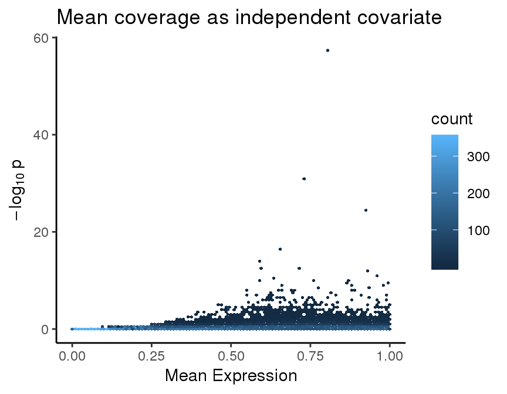

```r
rank_scatter(res, pvalue = "pval", covariate = "ind_covariate") +
    ggtitle("Mean coverage as independent covariate") +
    xlab("Mean Expression")
```

Similar to the GTEx dataset, keeping all the tests results in a strange discreteness. This is removed once we filter very lowly expressed genes. For the first covariate bin, however, there is a strange behaviour in which the distribution seems a bit skewed towards larger p-values.

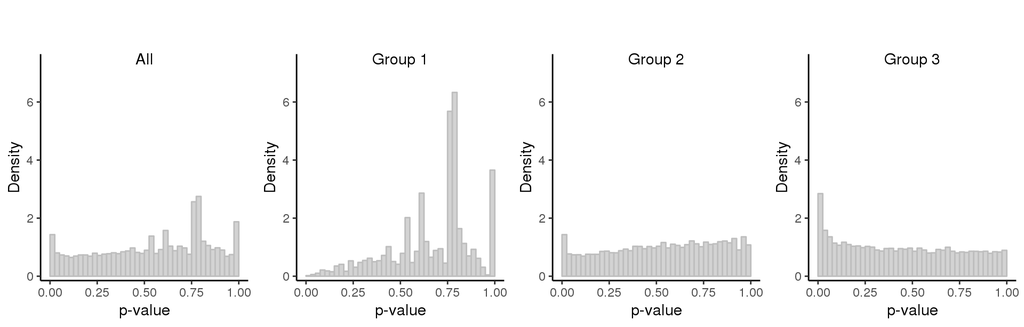

```r
strat_hist(res, pvalue = "pval",
           covariate = "ind_covariate", maxy = 7.5)
```

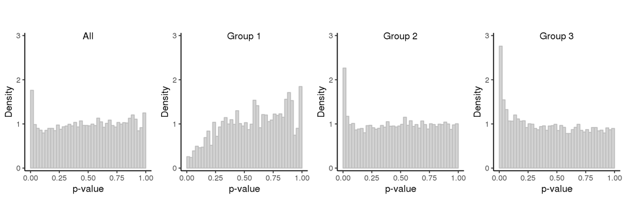

```r
res <- filter(res, ind_covariate > 1)
strat_hist(res, pvalue = "pval",
           covariate = "ind_covariate", maxy = 3)
```

### 4.2.2 Random

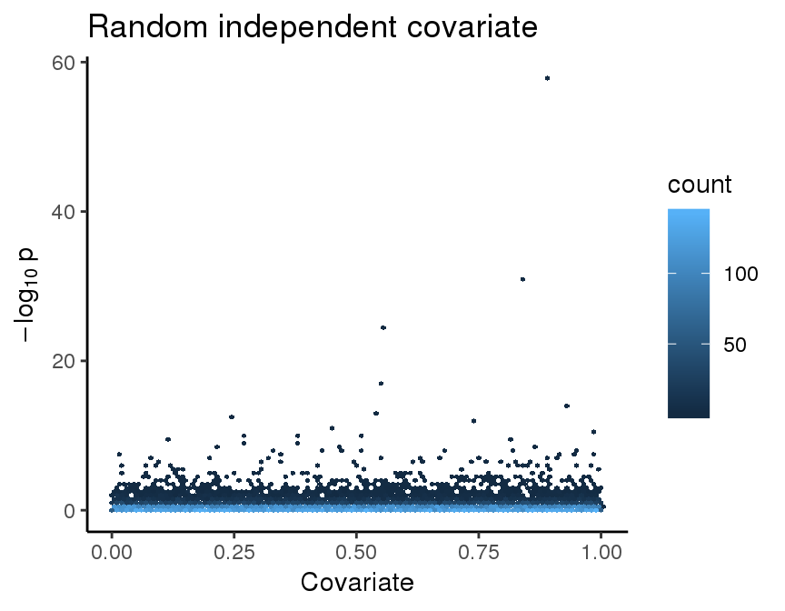

```r
rank_scatter(res, pvalue = "pval", covariate = "rand_covar") +
    ggtitle("Random independent covariate")
```

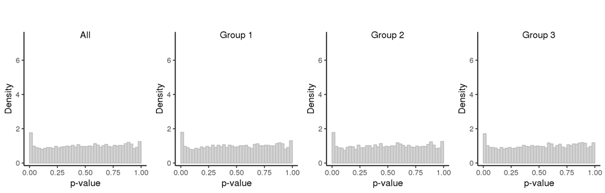

```r
strat_hist(res, pvalue = "pval",
           covariate = "rand_covar", maxy = 7.5)
```

## 4.3 Multiple-Testing Correction - mean

We use the common `BenchDesign` with the set of multiple testing correction methods already included. We also add in Scott’s FDR Regression (both `nulltype = "empirical"` and `nulltype = "theoretical"`) since our test statistics are t-distributed.

```r
if (file.exists(bench_file)) {
    sb <- readRDS(bench_file)
} else {
    bd <- initializeBenchDesign()

    bd <- addBMethod(bd, "fdrreg-t",
                     FDRreg::FDRreg,
                     function(x) { x$FDR },
                     z = test_statistic,
                     features = model.matrix( ~  splines::bs(ind_covariate, df = 3) - 1),
                     nulltype = 'theoretical',
                     control = list(lambda = 0.01))

   bd <- addBMethod(bd, "fdrreg-e",
                     FDRreg::FDRreg,
                     function(x) { x$FDR },
                     z = test_statistic,
                     features = model.matrix( ~  splines::bs(ind_covariate, df = 3) - 1),
                     nulltype = 'empirical',
                     control = list(lambda = 0.01))

    sb <- buildBench(bd, data = res, ftCols = "ind_covariate")
    saveRDS(sb, file = bench_file)
}
```

There are some warnings from both `BH` and `fdrreg-empirical`. However, they do return results. I tried to increase the `nmids` parameter for Scott’s FDR Regression but this does not appear to make a difference.

```r
head(assays(sb)[["bench"]])
```

```
##      unadjusted bonf        bh    qvalue   ihw-a01   ihw-a02   ihw-a03
## [1,]  0.6289835    1 0.9988806 0.9988806 0.9084923 0.9256538 0.9538953
## [2,]  0.7276542    1 0.9988806 0.9988806 1.0000000 1.0000000 1.0000000
## [3,]  0.9856426    1 0.9988806 0.9988806 1.0000000 1.0000000 1.0000000
## [4,]  0.5658651    1 0.9988806 0.9988806 0.9574543 1.0000000 0.9970605
## [5,]  0.7562462    1 0.9988806 0.9988806 1.0000000 1.0000000 1.0000000
## [6,]  0.1831689    1 0.9988806 0.9988806 0.7748361 0.7293789 0.7587335
##        ihw-a04   ihw-a05   ihw-a06   ihw-a07   ihw-a08   ihw-a09   ihw-a10
## [1,] 0.9399781 0.9477460 0.9079441 0.8867238 0.8920413 0.8938990 0.8875297
## [2,] 1.0000000 1.0000000 1.0000000 1.0000000 1.0000000 1.0000000 1.0000000
## [3,] 0.9115595 0.9805432 1.0000000 1.0000000 0.9829497 0.9995001 1.0000000
## [4,] 0.8728812 0.9211388 0.9273243 0.8693917 0.8743719 0.8877471 0.9233528
## [5,] 1.0000000 1.0000000 1.0000000 1.0000000 1.0000000 1.0000000 1.0000000
## [6,] 0.7443460 0.8010331 0.8550321 0.8951808 0.9322806 0.9550085 0.9014612
##           ashq   bl-df02   bl-df03   bl-df04   bl-df05      lfdr adapt-glm
## [1,] 0.6802749 0.9988806 0.9988806 0.9987813 0.9988806 0.8952599       Inf
## [2,] 0.6901540 0.9988806 0.9988806 0.9987719 0.9988804 0.9068889       Inf
## [3,] 0.6906848 0.9988806 0.9988806 0.9987803 0.9988806 0.9292130       Inf
## [4,] 0.6727982 0.9988806 0.9988806 0.9987793 0.9988806 0.8856500       Inf
## [5,] 0.5948722 0.9988806 0.9988806 0.9987854 0.9988806 0.9097459       Inf
## [6,] 0.5280837 0.9988806 0.9988806 0.9987717 0.9988803 0.5631366 0.6234639
##       fdrreg-t  fdrreg-e
## [1,] 0.9517631 0.8509272
## [2,] 0.9509362 0.8506307
## [3,] 0.9664806 0.8458035
## [4,] 0.9449457 0.8389268
## [5,] 0.9721130 0.8123192
## [6,] 0.8827712 0.4987177
```

## 4.4 Benchmark Metrics - mean

`fdrreg-empirical` rejects many more hypothesis than the rest of the methods, followed by `lfdr` and `ihw`.

```r
assayNames(sb) <- "qvalue"
sb <- addDefaultMetrics(sb)
estimatePerformanceMetrics(sb, alpha = 0.05, tidy = TRUE) %>%
    filter(performanceMetric == "rejections") %>%
    select(blabel, performanceMetric, alpha, value) %>%
    mutate(n = nrow(sb), prop = round(value / n, 3)) %>%
    arrange(desc(value)) %>%
    as_tibble() %>%
    print(n = 40)
```

```
## # A tibble: 23 x 6
##    blabel     performanceMetric alpha value     n  prop
##    <chr>      <chr>             <dbl> <dbl> <int> <dbl>
##  1 unadjusted rejections         0.05  1947 28345 0.069
##  2 fdrreg-e   rejections         0.05   602 28345 0.021
##  3 lfdr       rejections         0.05   338 28345 0.012
##  4 ihw-a04    rejections         0.05   289 28345 0.01
##  5 ihw-a05    rejections         0.05   289 28345 0.01
##  6 ihw-a02    rejections         0.05   287 28345 0.01
##  7 ihw-a03    rejections         0.05   285 28345 0.01
##  8 ihw-a07    rejections         0.05   283 28345 0.01
##  9 ihw-a10    rejections         0.05   281 28345 0.01
## 10 ashq       rejections         0.05   281 28345 0.01
## 11 ihw-a08    rejections         0.05   280 28345 0.01
## 12 ihw-a09    rejections         0.05   279 28345 0.01
## 13 ihw-a01    rejections         0.05   278 28345 0.01
## 14 ihw-a06    rejections         0.05   275 28345 0.01
## 15 fdrreg-t   rejections         0.05   250 28345 0.009
## 16 bl-df02    rejections         0.05   245 28345 0.009
## 17 bh         rejections         0.05   243 28345 0.009
## 18 qvalue     rejections         0.05   243 28345 0.009
## 19 bl-df03    rejections         0.05   243 28345 0.009
## 20 bl-df04    rejections         0.05   243 28345 0.009
## 21 bl-df05    rejections         0.05   243 28345 0.009
## 22 adapt-glm  rejections         0.05   229 28345 0.008
## 23 bonf       rejections         0.05    68 28345 0.002
```

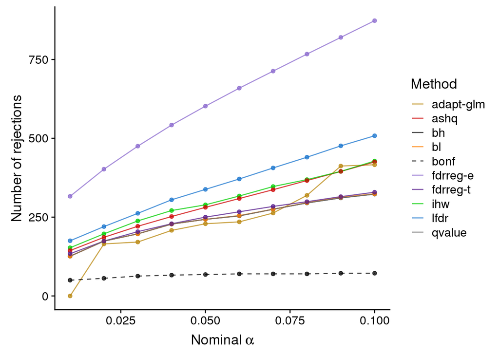

```r
rejections_scatter(sb, supplementary = FALSE)
```

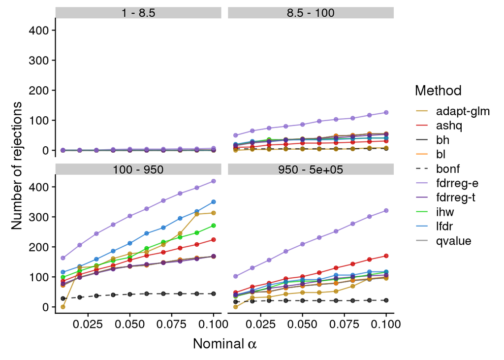

```r
rejection_scatter_bins(sb, covariate = "ind_covariate",
                       bins = 4, supplementary = FALSE)
```

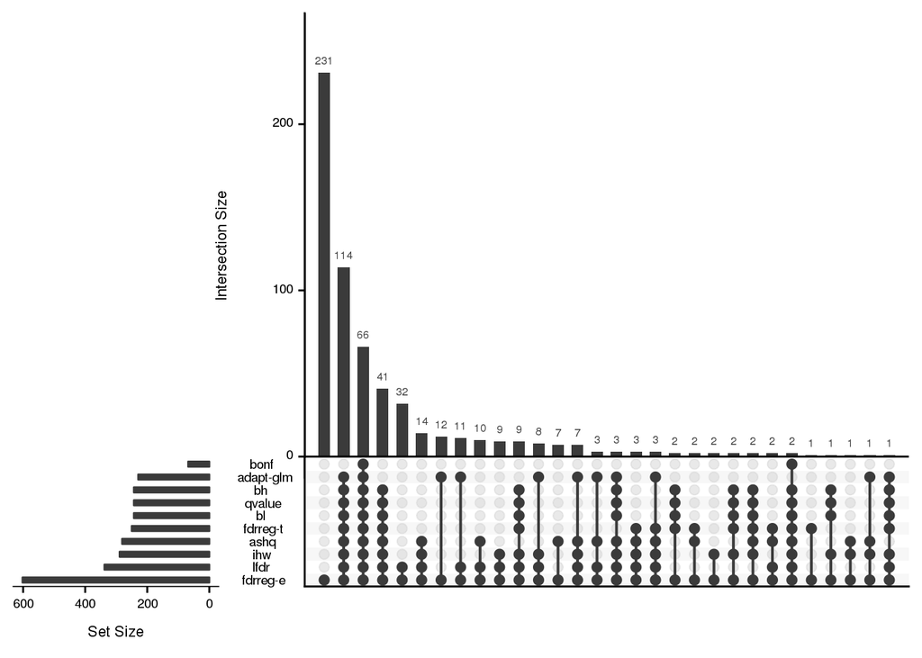

```r
plotFDRMethodsOverlap(sb, alpha = 0.05, nsets = ncol(sb),
                      order.by = "freq", decreasing = TRUE,
                      supplementary = FALSE)
```

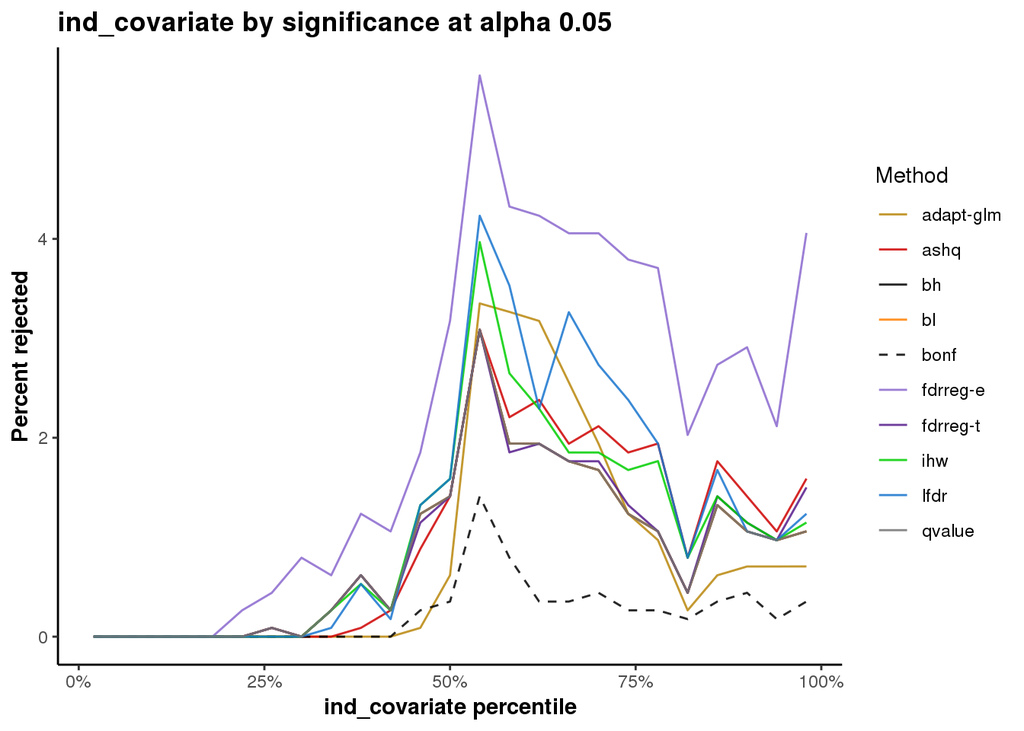

```r
covariateLinePlot(sb, alpha = 0.05, covname = "ind_covariate")
```

## 4.5 Multiple-Testing Correction - random

We use the common `BenchDesign` with the set of multiple testing correction methods already included. We also add in Scott’s FDR Regression (both `nulltype = "empirical"` and `nulltype = "theoretical"`) since our test statistics are t-distributed.

```r
if (file.exists(bench_file_uninf)) {
    sb <- readRDS(bench_file_uninf)
} else {
    bd <- initializeBenchDesign()

    bd <- addBMethod(bd, "fdrreg-t",
                     FDRreg::FDRreg,
                     function(x) { x$FDR },
                     z = test_statistic,
                     features = model.matrix( ~  splines::bs(ind_covariate, df = 3) - 1),
                     nulltype = 'theoretical',
                     control = list(lambda = 0.01))

   bd <- addBMethod(bd, "fdrreg-e",
                     FDRreg::FDRreg,
                     function(x) { x$FDR },
                     z = test_statistic,
                     features = model.matrix( ~  splines::bs(ind_covariate, df = 3) - 1),
                     nulltype = 'empirical',
                     control = list(lambda = 0.01))

    res <- res %>% dplyr::mutate(ind_covariate = rand_covar)
    sb <- buildBench(bd, data = res, ftCols = "ind_covariate")
    saveRDS(sb, file = bench_file_uninf)
}
```

```r
head(assays(sb)[["bench"]])
```

```
##      unadjusted bonf        bh    qvalue ihw-a01 ihw-a02 ihw-a03   ihw-a04
## [1,]  0.6289835    1 0.9988806 0.9988806       1       1       1 1.0000000
## [2,]  0.7276542    1 0.9988806 0.9988806       1       1       1 1.0000000
## [3,]  0.9856426    1 0.9988806 0.9988806       1       1       1 1.0000000
## [4,]  0.5658651    1 0.9988806 0.9988806       1       1       1 1.0000000
## [5,]  0.7562462    1 0.9988806 0.9988806       1       1       1 1.0000000
## [6,]  0.1831689    1 0.9988806 0.9988806       1       1       1 0.9993566
##       ihw-a05   ihw-a06  ihw-a07   ihw-a08   ihw-a09   ihw-a10      ashq
## [1,] 1.000000 1.0000000 1.000000 0.9988806 1.0000000 1.0000000 0.6802749
## [2,] 1.000000 1.0000000 1.000000 0.9988806 1.0000000 1.0000000 0.6901540
## [3,] 1.000000 1.0000000 1.000000 0.9988806 1.0000000 1.0000000 0.6906848
## [4,] 1.000000 1.0000000 1.000000 0.9988806 1.0000000 1.0000000 0.6727982
## [5,] 1.000000 1.0000000 1.000000 0.9988806 1.0000000 1.0000000 0.5948722
## [6,] 0.981229 0.9963752 0.996976 0.9988806 0.9920812 0.9945771 0.5280837
##        bl-df02   bl-df03   bl-df04   bl-df05      lfdr adapt-glm  fdrreg-t
## [1,] 0.9988806 0.9988806 0.9987791 0.9988806 0.9389829       Inf 0.9545476
## [2,] 0.9988806 0.9988806 0.9987752 0.9988806 0.9815271       Inf 0.9590348
## [3,] 0.9988806 0.9988806 0.9987878 0.9988806 0.9853928       Inf 0.9738564
## [4,] 0.9988806 0.9988806 0.9987737 0.9988806 0.9780420       Inf 0.9476087
## [5,] 0.9988806 0.9988806 0.9987848 0.9988806 0.9820017       Inf 0.9735677
## [6,] 0.9988806 0.9988806 0.9987812 0.9988806 0.9634040   1.05848 0.8857965
##       fdrreg-e
## [1,] 0.8564327
## [2,] 0.8704705
## [3,] 0.8393779
## [4,] 0.8463939
## [5,] 0.8013781
## [6,] 0.5075351
```

## 4.6 Benchmark Metrics - random

```r
assayNames(sb) <- "qvalue"
sb <- addDefaultMetrics(sb)
estimatePerformanceMetrics(sb, alpha = 0.05, tidy = TRUE) %>%
    filter(performanceMetric == "rejections") %>%
    select(blabel, performanceMetric, alpha, value) %>%
    mutate(n = nrow(sb), prop = round(value / n, 3)) %>%
    arrange(desc(value)) %>%
    as_tibble() %>%
    print(n = 40)
```

```
## # A tibble: 23 x 6
##    blabel     performanceMetric alpha value     n  prop
##    <chr>      <chr>             <dbl> <dbl> <int> <dbl>
##  1 unadjusted rejections         0.05  1947 28345 0.069
##  2 fdrreg-e   rejections         0.05   588 28345 0.021
##  3 ashq       rejections         0.05   281 28345 0.01
##  4 lfdr       rejections         0.05   251 28345 0.009
##  5 fdrreg-t   rejections         0.05   249 28345 0.009
##  6 ihw-a10    rejections         0.05   245 28345 0.009
##  7 bh         rejections         0.05   243 28345 0.009
##  8 qvalue     rejections         0.05   243 28345 0.009
##  9 ihw-a02    rejections         0.05   243 28345 0.009
## 10 ihw-a08    rejections         0.05   243 28345 0.009
## 11 ihw-a09    rejections         0.05   243 28345 0.009
## 12 bl-df02    rejections         0.05   243 28345 0.009
## 13 bl-df03    rejections         0.05   243 28345 0.009
## 14 bl-df04    rejections         0.05   243 28345 0.009
## 15 bl-df05    rejections         0.05   243 28345 0.009
## 16 ihw-a03    rejections         0.05   239 28345 0.008
## 17 ihw-a04    rejections         0.05   239 28345 0.008
## 18 ihw-a05    rejections         0.05   239 28345 0.008
## 19 ihw-a06    rejections         0.05   236 28345 0.008
## 20 ihw-a07    rejections         0.05   236 28345 0.008
## 21 ihw-a01    rejections         0.05   233 28345 0.008
## 22 bonf       rejections         0.05    68 28345 0.002
## 23 adapt-glm  rejections         0.05    62 28345 0.002
```

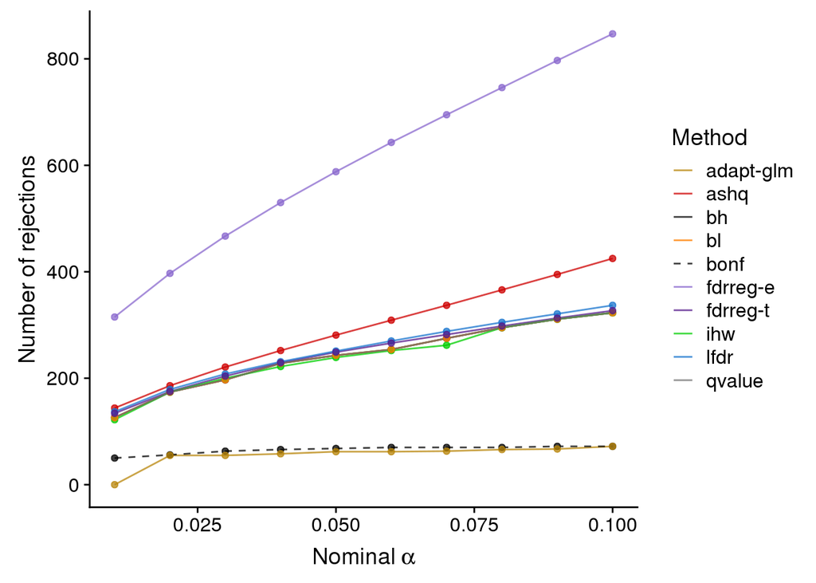

```r
rejections_scatter(sb, supplementary = FALSE)
```

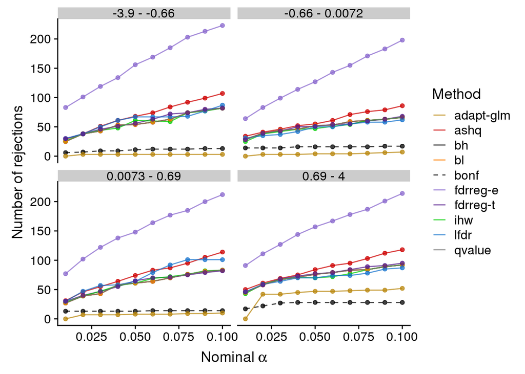

```r
rejection_scatter_bins(sb, covariate = "ind_covariate",
                       bins = 4, supplementary = FALSE)
```

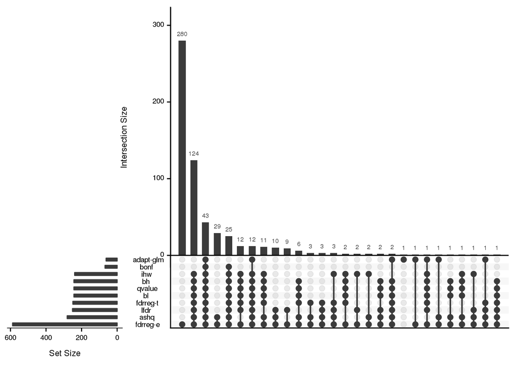

```r
plotFDRMethodsOverlap(sb, alpha = 0.05, nsets = ncol(sb),
                      order.by = "freq", decreasing = TRUE,
                      supplementary = FALSE)
```

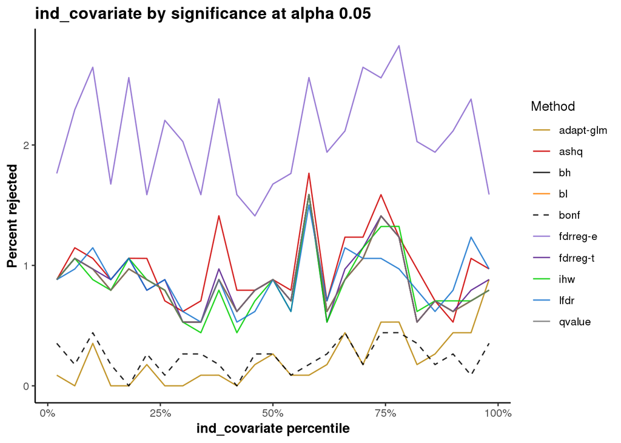

```r
covariateLinePlot(sb, alpha = 0.05, covname = "ind_covariate")
```

# 5 Covariate comparison

Here we compare the method ranks for the different covariates at alpha = 0.10.

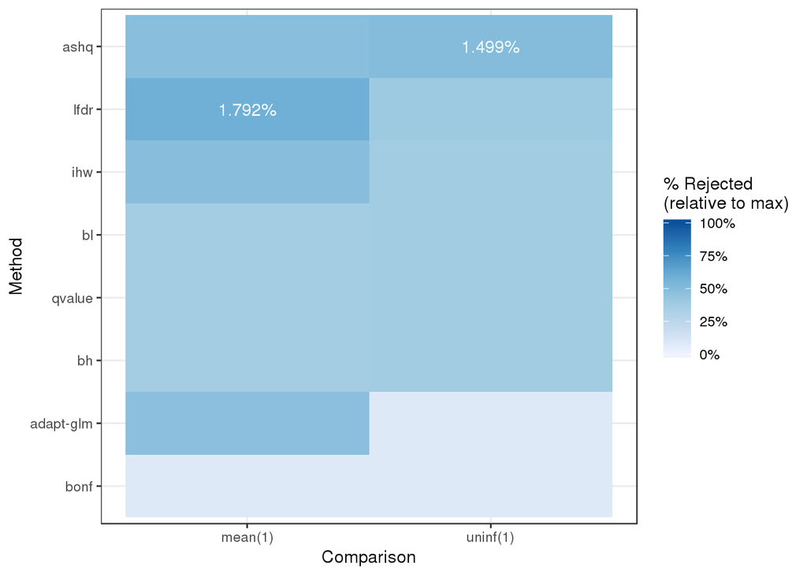

```r
plotMethodRanks(c(bench_file, bench_file_uninf),
                colLabels = c("mean", "uninf"),
                alpha = 0.10, xlab = "Comparison")
```